# Beta diversity – Bray-Curtis dissimilarity

## Data preparation

```r
library(sauerkrautTaxonomyBuddy)
library(SummarizedExperiment) # microbiome analysis
library(vegan)                # distance metric calculation

library(scater)     # dimension reduction and visualizations
library(mgcv)       # estimate smooth surfaces with gam()
library(APCtools)   # gam visualization

library(dplyr)      # data handling
library(tidyr)      # data transformation
library(ggplot2)    # data visualization
library(patchwork)  # aligning ggplot objects in a grid
library(ggpubr)     # further ggplot convenience functions
library(kableExtra) # table printing

# set ggplot2 theme
theme_set(
  theme_minimal() +
    theme(plot.title = element_text(hjust = 0.5),
          plot.subtitle    = element_text(hjust = 0.5),
          plot.background  = element_rect(fill = "white", color = "white"))
)
```

```r
define_dataPaths()
```

```r
tse <- readAndPrepare_mainTaxonomicData(path_groupInfoRdata               = path_groupInfoRdata,
                                        path_participantRdata             = path_participantRdata,
                                        path_samplesIDxlsx                = path_samplesIDxlsx,
                                        path_dietInfoCsv                  = path_dietInfoCsv,
                                        path_nutrientInfoCsv              = path_nutrientInfoCsv,
                                        path_bloodMetabolomeXlsx          = path_bloodMetabolomeXlsx,
                                        path_stoolMetabolomeXlsx          = path_stoolMetabolomeXlsx,
                                        path_T4questXlsx                  = path_T4questXlsx,
                                        path_stoolInfoXlsx                = path_stoolInfoXlsx,
                                        path_bodyMeasuresXlsx             = path_bodyMeasuresXlsx,
                                        path_absTaxonomyData              = path_absTaxonomyData,
                                        path_relTaxonomyData              = path_relTaxonomyData,
                                        path_sampleLookupXlsx             = path_sampleLookupXlsx,
                                        path_krautLookupXlsx              = path_krautLookupXlsx,
                                        path_bloodMarkerBostonRdata       = path_bloodMarkerBostonRdata,
                                        path_bloodMarkerZentrallaborRdata = path_bloodMarkerZentrallaborRdata,
                                        path_bloodMarkerBostonXlsx        = path_bloodMarkerBostonXlsx,
                                        path_bloodMarkerZentrallaborXlsx  = path_bloodMarkerZentrallaborXlsx,
                                        aggregation_level                 = "species",
                                        exclude_sickParticipants          = "taxonomy paper")

# add further features to colData(tse)
tse <- tse_addTaxaFeatures(tse          = tse,
                           assay_relAbd = "relAbd")

# save colData() as a separate data.frame
dat <- tse %>% colData() %>% as.data.frame()
```

```r
# add strata information
dat <- dat %>%
  mutate(age_cat        = case_when(age < 50 ~ paste0(min(age), "-49"),
                                    TRUE     ~ paste0("50-", max(age))),
         age_cat        = factor(age_cat),
         bmi_cat        = case_when(bmi_t0 < 25 ~ paste0("[", floor(min(bmi_t0)), ", 25)"),
                                    TRUE        ~ paste0("[25, ", ceiling(max(bmi_t0)), "]")),
         bmi_cat        = factor(bmi_cat))
```

```r
set.seed(2025)
tse <- tse %>% runUMAP(name = "UMAP", exprs_values = "relAbd")

dat_UMAP <- tse %>% reducedDim("UMAP") %>% dplyr::bind_cols(dat)
```

# Calculate Bray-Curtis dissimilarity matrix

Bray-Curtis dissimilarities are calculated based on the relative abundances, following the [Introduction to Microbiome Data Science](https://microbiome.github.io/course_2021_radboud/beta-diversity.html#pcoa-for-asv-level-data-with-bray-curtis) book.

```r
datDist_list <- calculate_distances(tse, "relAbd")

datDist_intra <- datDist_list$datDist_intraPersonal
datDist_inter <- datDist_list$datDist_interPersonal
```

The pairwise Bray-Curtis dissimilarities in our sample vary between 0.14 and 0.81 regarding the intra-personal variability and between 0.3 and 1 regarding the inter-personal variability. The Bray-Curtis dissimilarities have the following distribution:

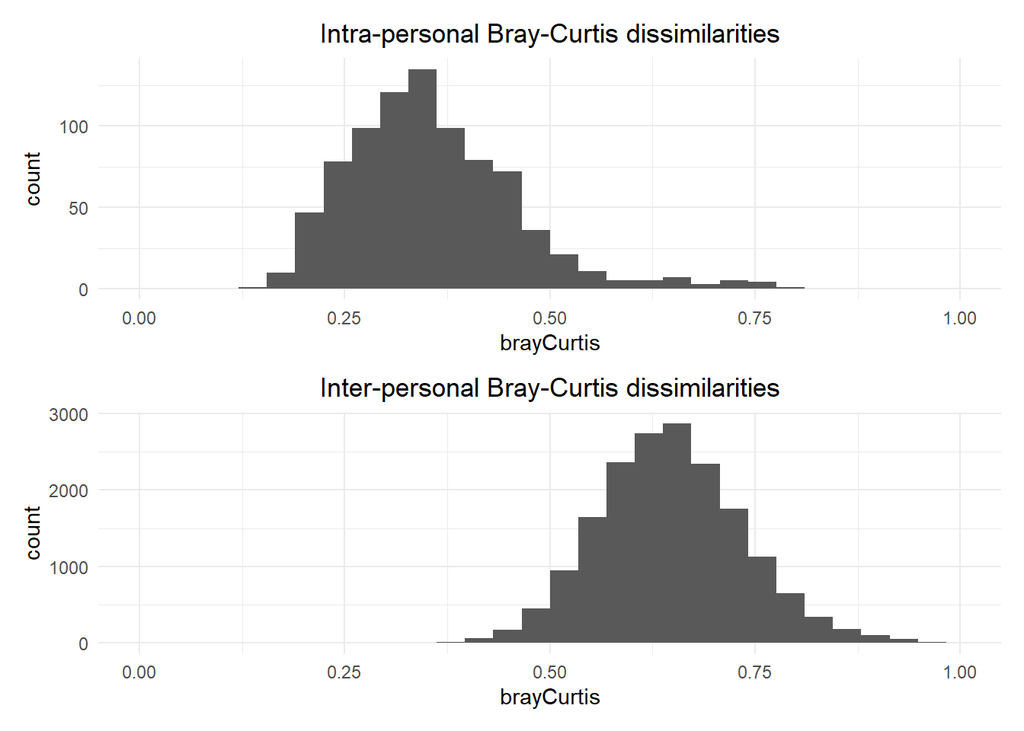

```r
gg1 <- ggplot(datDist_intra, aes(x = brayCurtis)) + geom_histogram() + xlim(c(0,1)) + ggtitle("Intra-personal Bray-Curtis dissimilarities")
gg2 <- ggplot(datDist_inter, aes(x = brayCurtis)) + geom_histogram() + xlim(c(0,1)) + ggtitle("Inter-personal Bray-Curtis dissimilarities")

gg1 / gg2
```

# Figure for publication

Comparing unweighted and weighted UniFrac with Bray-Curtis.

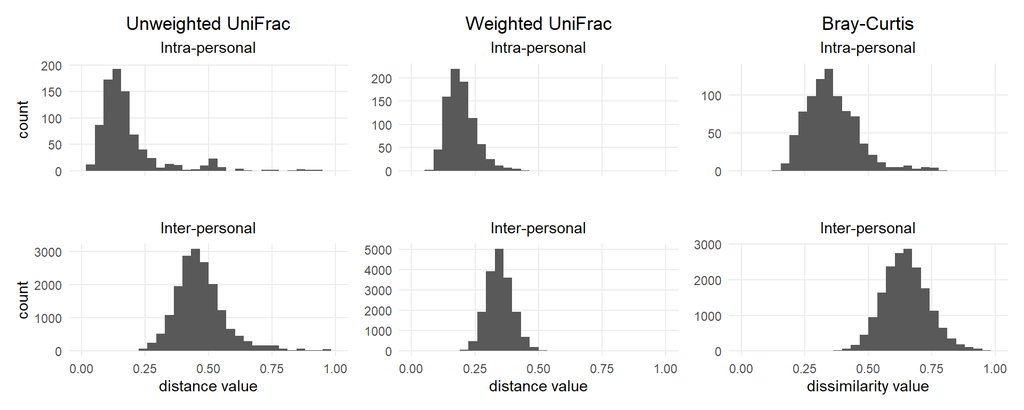

```r
# unweighted UniFrac
gg_uUF1 <- ggplot(datDist_intra, aes(x = uniFrac_unweighted)) + geom_histogram() + xlim(c(0,1)) + ggtitle("Unweighted UniFrac", "Intra-personal") +
  theme(panel.grid.minor = element_blank(),
        axis.title.x     = element_blank(),
        axis.text.x      = element_blank())
gg_uUF2 <- ggplot(datDist_inter, aes(x = uniFrac_unweighted)) + geom_histogram() + xlim(c(0,1)) + ggtitle("", "Inter-personal") + xlab("distance value") + theme(panel.grid.minor = element_blank())

# weighted UniFrac
gg_wUF1 <- ggplot(datDist_intra, aes(x = uniFrac_weighted)) + geom_histogram() + xlim(c(0,1)) + ggtitle("Weighted UniFrac", "Intra-personal") +
  theme(panel.grid.minor = element_blank(),
        axis.title       = element_blank(),
        axis.text.x      = element_blank())
gg_wUF2 <- ggplot(datDist_inter, aes(x = uniFrac_weighted)) + geom_histogram() + xlim(c(0,1)) + ggtitle("", "Inter-personal") + xlab("distance value") +
  theme(panel.grid.minor = element_blank(),
        axis.title.y     = element_blank())

# Bray-Curtis
gg_bc1 <- ggplot(datDist_intra, aes(x = brayCurtis)) + geom_histogram() + xlim(c(0,1)) + ggtitle("Bray-Curtis", "Intra-personal") +
  theme(panel.grid.minor = element_blank(),
        axis.title       = element_blank(),
        axis.text.x      = element_blank())
gg_bc2 <- ggplot(datDist_inter, aes(x = brayCurtis)) + geom_histogram() + xlim(c(0,1)) + ggtitle("", "Inter-personal") + xlab("dissimilarity value") +
  theme(panel.grid.minor = element_blank(),
        axis.title.y     = element_blank())

layout <- "
ABC
DEF
"
gg_uUF1 + gg_wUF1 + gg_bc1 + gg_uUF2 + gg_wUF2 + gg_bc2 + patchwork::plot_layout(design = layout)
```

```r
# ggsave("FigureS4_InterIntraBetaDiversity.png", width = 10, height = 4)
```

# Intra-personal variation

1. For each timepoint comparison (e.g. *T1 vs. T3*) one Bray-Curtis dissimilarity was calculated per person
2. The following boxplots all depict such comparisons where one timepoint measurement of a person was compared to another timepoint measurement of the same person. Accordingly, each point encodes **intra-personal variation**.
3. The displayed dissimilarities vary between 0 (*perfect similarity*) and 1 (*no similarity at all*).

## Development over the timepoints

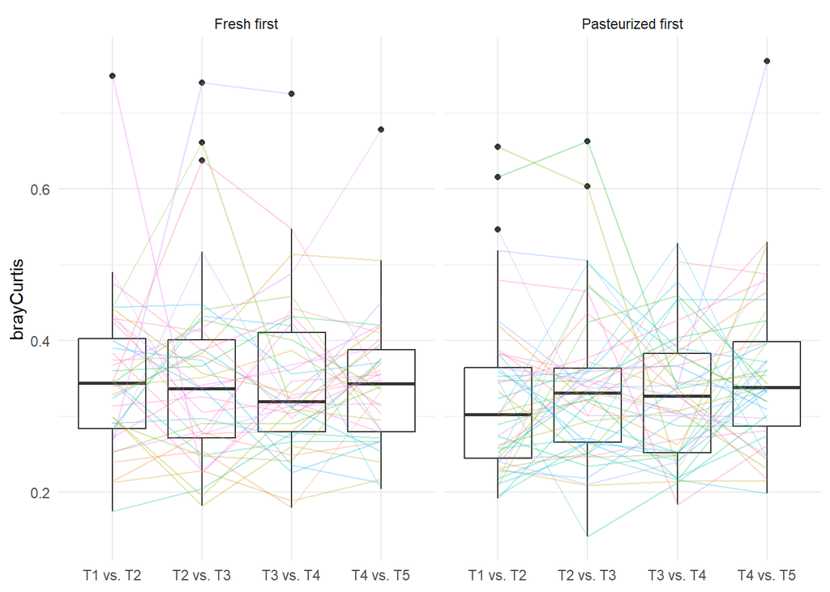

```r
datDist_intra %>%
  filter(comparison %in% c("T1 vs. T2", "T2 vs. T3", "T3 vs. T4", "T4 vs. T5")) %>%
  ggplot(aes(x = comparison, y = brayCurtis)) +
  geom_boxplot() +
  geom_line(aes(group = participant_id, col = participant_id), alpha = 0.3) +
  facet_wrap(~ group) +
  theme(axis.title.x    = element_blank(),
        legend.position = "none")
```

## Variation by intervention

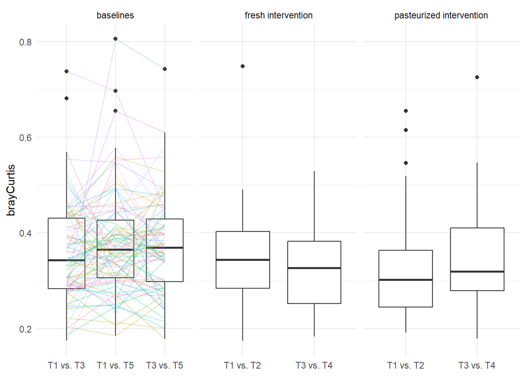

```r
datDist_intra %>%
  filter(comparison_group != "other") %>%
  ggplot(aes(x = comparison, y = brayCurtis)) +
  geom_boxplot() +
  geom_line(aes(group = participant_id, col = participant_id), alpha = 0.3) +
  facet_wrap(~ comparison_group, scales = "free_x") +
  theme(axis.title.x    = element_blank(),
        legend.position = "none")
```

### Figure for publication

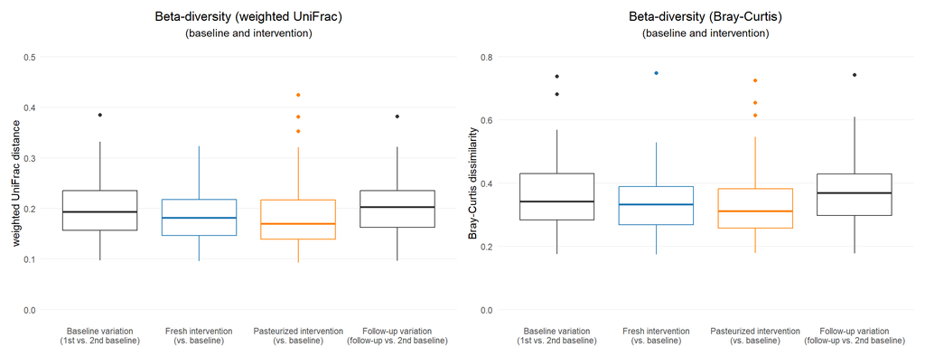

```r
dat_plot <- datDist_intra %>%
  filter(comparison_group != "other",
         comparison != "T1 vs. T5") %>%
  mutate(comparison_group = case_when(comparison_group == "baselines" & comparison == "T1 vs. T3" ~ "Baseline variation\n(1st vs. 2nd baseline)",
                                      comparison_group == "baselines" & comparison == "T3 vs. T5" ~ "Follow-up variation\n(follow-up vs. 2nd baseline)",
                                      comparison_group == "fresh intervention"                    ~ "Fresh intervention\n(vs. baseline)",
                                      comparison_group == "pasteurized intervention"              ~ "Pasteurized intervention\n(vs. baseline)"),
         comparison_group = factor(comparison_group,
                                   levels = c("Baseline variation\n(1st vs. 2nd baseline)", "Fresh intervention\n(vs. baseline)",
                                              "Pasteurized intervention\n(vs. baseline)", "Follow-up variation\n(follow-up vs. 2nd baseline)")))

# weighted UniFrac
gg_betaDiv_wUF <- dat_plot %>%
  ggplot(aes(x = comparison_group, y = uniFrac_weighted, col = comparison_group)) +
  geom_boxplot() +
  scale_y_continuous("weighted UniFrac distance", limits = c(0, .5)) +
  scale_color_manual(values = c("gray20","#1F78B4","#FF7F00","gray20")) +
  ggtitle("Beta-diversity (weighted UniFrac)", "(baseline and intervention)") +
  theme(axis.title.x    = element_blank(),
        legend.position = "none",
        panel.grid.minor   = element_blank(),
        panel.grid.major.x = element_blank(),
        panel.grid.major.y = element_line(color = "gray95"))

# Bray-Curtis
gg_betaDiv_bc <- dat_plot %>%
  ggplot(aes(x = comparison_group, y = brayCurtis, col = comparison_group)) +
  geom_boxplot() +
  scale_y_continuous("Bray-Curtis dissimilarity", limits = c(0, .8)) +
  scale_color_manual(values = c("gray20","#1F78B4","#FF7F00","gray20")) +
  ggtitle("Beta-diversity (Bray-Curtis)", "(baseline and intervention)") +
  theme(axis.title.x    = element_blank(),
        legend.position = "none",
        panel.grid.minor   = element_blank(),
        panel.grid.major.x = element_blank(),
        panel.grid.major.y = element_line(color = "gray95"))

gg_betaDiv_wUF + gg_betaDiv_bc
```

```r
# ggsave("FigureS6_betaDiversity.png", width = 13, height = 5)
```

### Same figure, just with unweighted UniFrac instead of Bray-Curtis

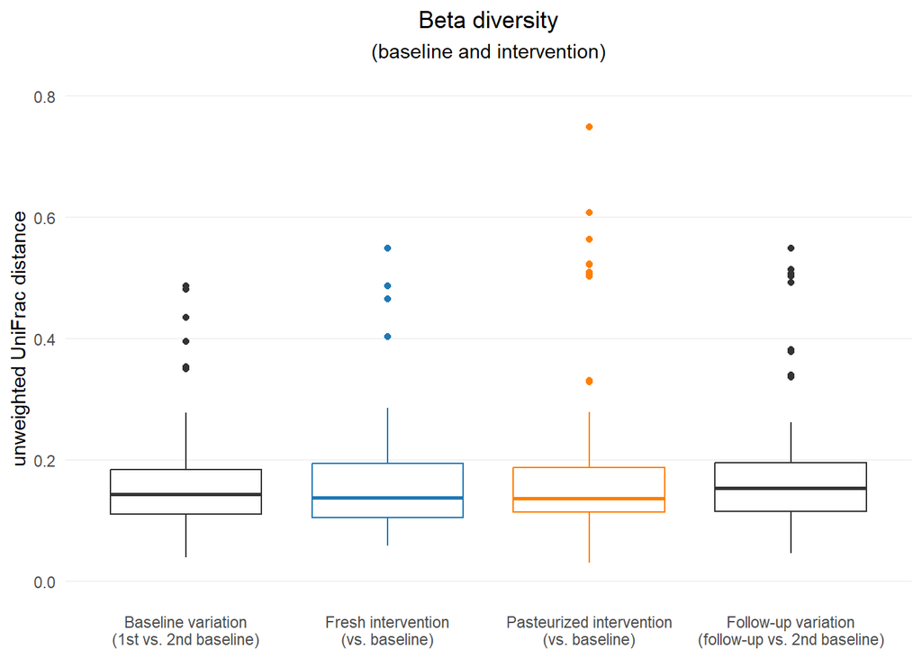

```r
gg_betaDiv_uuf <- datDist_intra %>%
  filter(comparison_group != "other",
         comparison != "T1 vs. T5") %>%
  mutate(comparison_group = case_when(comparison_group == "baselines" & comparison == "T1 vs. T3" ~ "Baseline variation\n(1st vs. 2nd baseline)",
                                      comparison_group == "baselines" & comparison == "T3 vs. T5" ~ "Follow-up variation\n(follow-up vs. 2nd baseline)",
                                      comparison_group == "fresh intervention"                    ~ "Fresh intervention\n(vs. baseline)",
                                      comparison_group == "pasteurized intervention"              ~ "Pasteurized intervention\n(vs. baseline)"),
         comparison_group = factor(comparison_group,
                                   levels = c("Baseline variation\n(1st vs. 2nd baseline)", "Fresh intervention\n(vs. baseline)",
                                              "Pasteurized intervention\n(vs. baseline)", "Follow-up variation\n(follow-up vs. 2nd baseline)"))) %>%
  ggplot(aes(x = comparison_group, y = uniFrac_unweighted, col = comparison_group)) +
  geom_boxplot() +
  scale_y_continuous("unweighted UniFrac distance", limits = c(0, .8)) +
  scale_color_manual(values = c("gray20","#1F78B4","#FF7F00","gray20")) +
  ggtitle("Beta diversity", "(baseline and intervention)") +
  theme(axis.title.x    = element_blank(),
        legend.position = "none",
        panel.grid.minor   = element_blank(),
        panel.grid.major.x = element_blank(),
        panel.grid.major.y = element_line(color = "gray95"))
gg_betaDiv_uuf
```

```r
# ggsave("betaDiversity_unweightedUniFrac.png", width = 6.8, height = 5)
```

## Variation vs. microbiome diversity

Based on the intra-personal Bray-Curtis dissimilarities between the *T1 vs. T2* and the *T3 vs. T4* measurements, the following plots visualize the assocation between these dissimilarities and the people’s microbiota diversity at the respective baseline (T1 or T3).  
Shannon diversity and inverse Simpson diversity are used as microbiota diversity measures.

**Hypothesis:** The higher the microbiota diversity of the baseline, the more stable the microbiota.

```r
datDist_intra <- datDist_intra %>%
  mutate(part_time = paste0(participant_id, "_", timepoint_1)) %>%
  dplyr::left_join(dat %>% select(part_time, age_cat, bmi_cat, intervention, diversity_shannon, diversity_invSimpson), by = "part_time") %>%
  select(-part_time)
```

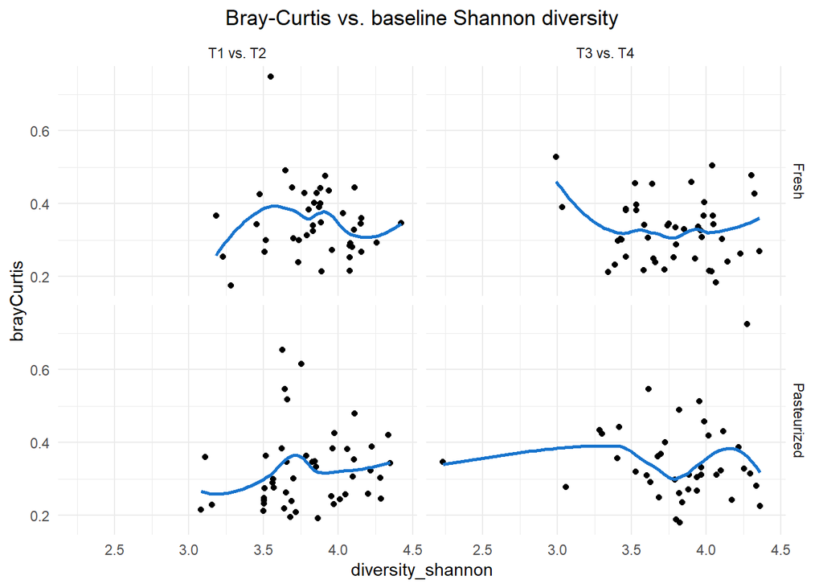

```r
# Shannon diversity
datDist_intra %>%
  filter(comparison %in% c("T1 vs. T2", "T3 vs. T4")) %>%
  ggplot(aes(x = diversity_shannon, y = brayCurtis)) +
  geom_point() +
  geom_smooth(se = FALSE, col = "dodgerblue3") +
  facet_grid(rows = vars(intervention), cols = vars(comparison)) +
  ggtitle("Bray-Curtis vs. baseline Shannon diversity")
```

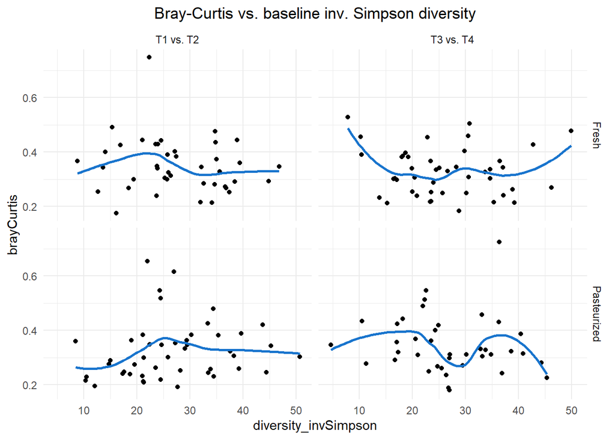

```r
# inverse Simpson diversity
datDist_intra %>%
  filter(comparison %in% c("T1 vs. T2", "T3 vs. T4")) %>%
  ggplot(aes(x = diversity_invSimpson, y = brayCurtis)) +
  geom_point() +
  geom_smooth(se = FALSE, col = "dodgerblue3") +
  facet_grid(rows = vars(intervention), cols = vars(comparison)) +
  ggtitle("Bray-Curtis vs. baseline inv. Simpson diversity")
```

### Figure for publication

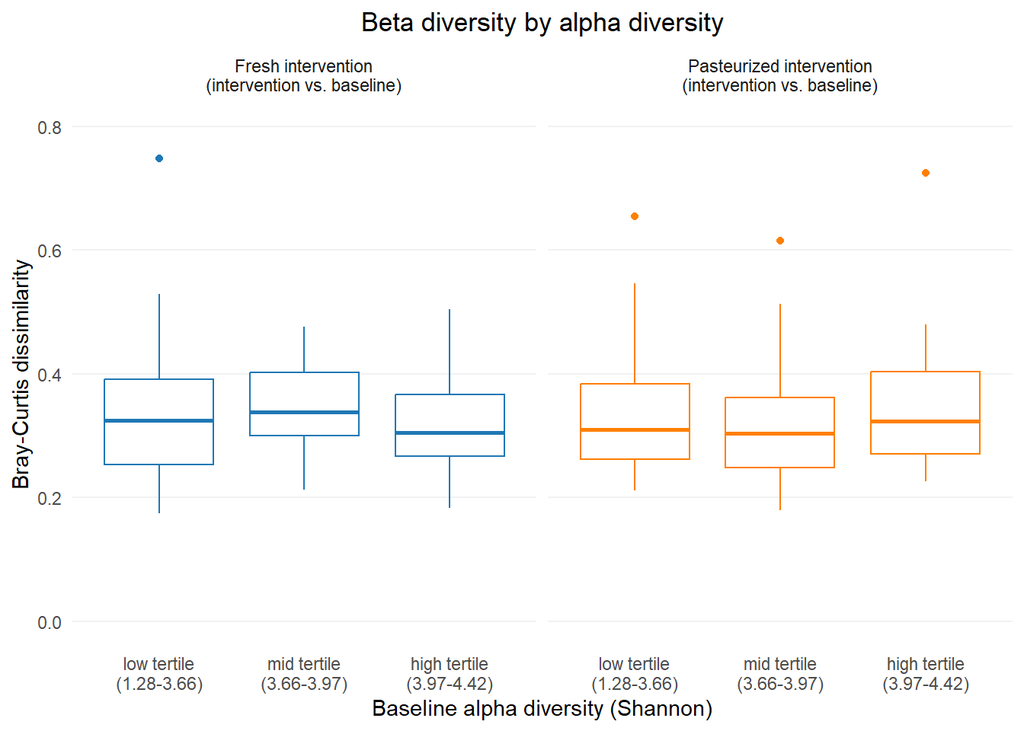

```r
# plot with categorized alpha diversity
divShannon_tertiles <- quantile(dat$diversity_shannon, probs = c(0, 1/3, 2/3, 1))
tertiles_rounded    <- divShannon_tertiles %>% round(2) %>% unname()
tertile_labels      <- c(paste0("low tertile\n(", tertiles_rounded[1],"-",tertiles_rounded[2],")"),
                         paste0("mid tertile\n(", tertiles_rounded[2],"-",tertiles_rounded[3],")"),
                         paste0("high tertile\n(",tertiles_rounded[3],"-",tertiles_rounded[4],")"))
gg_betaVSalpha_cat <- datDist_intra %>%
  filter(comparison_group %in% c("fresh intervention", "pasteurized intervention")) %>%
  mutate(diversity_shannon_cat = case_when(diversity_shannon < divShannon_tertiles[2] ~ tertile_labels[1],
                                           diversity_shannon < divShannon_tertiles[3] ~ tertile_labels[2],
                                           TRUE ~ tertile_labels[3]),
         diversity_shannon_cat = factor(diversity_shannon_cat, levels = tertile_labels),
         comparison_group      = case_when(comparison_group == "fresh intervention" ~ "Fresh intervention\n(intervention vs. baseline)",
                                           comparison_group == "pasteurized intervention" ~ "Pasteurized intervention\n(intervention vs. baseline)")) %>%
  ggplot(aes(x = diversity_shannon_cat, y = brayCurtis, col = comparison_group)) +
  geom_boxplot() +
  scale_color_manual(values = c("#1F78B4","#FF7F00")) +
  facet_wrap(~ comparison_group) +
  ggtitle("Beta diversity by alpha diversity") +
  xlab("Baseline alpha diversity (Shannon)") +
  scale_y_continuous("Bray-Curtis dissimilarity", limits = c(0, .8)) +
  theme(legend.position    = "none",
        panel.grid.minor   = element_blank(),
        panel.grid.major.x = element_blank(),
        panel.grid.major.y = element_line(color = "gray95"))
gg_betaVSalpha_cat
```

```r
# ggsave("betaDivByAlphaDiv_brayCurtis_cat.png", width = 6.8, height = 5)
```

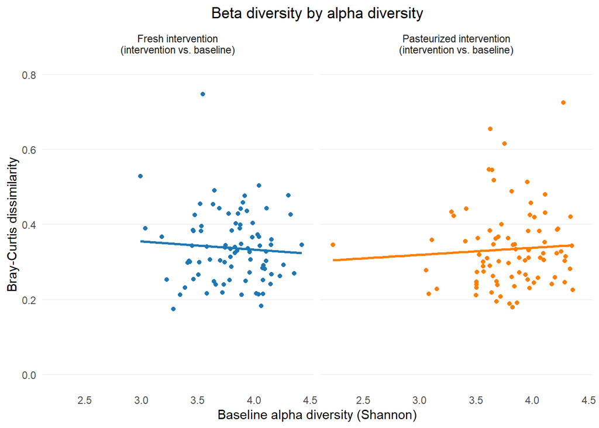

```r
# plot with metric alpha diversity
dat_comparison2 <- datDist_intra %>%
  filter(comparison_group %in% c("fresh intervention", "pasteurized intervention"))

gg_betaVSalpha <- dat_comparison2 %>%
  mutate(comparison_group = case_when(comparison_group == "fresh intervention" ~ "Fresh intervention\n(intervention vs. baseline)",
                                      comparison_group == "pasteurized intervention" ~ "Pasteurized intervention\n(intervention vs. baseline)")) %>%
  ggplot(aes(x = diversity_shannon, y = brayCurtis, col = comparison_group)) +
  geom_point() +
  scale_color_manual(values = c("#1F78B4","#FF7F00")) +
  geom_smooth(se = FALSE, method = "lm") +
  facet_wrap(~ comparison_group) +
  ggtitle("Beta diversity by alpha diversity") +
  xlab("Baseline alpha diversity (Shannon)") +
  scale_y_continuous("Bray-Curtis dissimilarity", limits = c(0, .8)) +
  theme(legend.position    = "none",
        panel.grid.minor   = element_blank(),
        panel.grid.major.x = element_blank(),
        panel.grid.major.y = element_line(color = "gray95"))
gg_betaVSalpha
```

```r
# ggsave("betaDivByAlphaDiv_brayCurtis.png", width = 6.8, height = 5)

# correlation test in each comparison group
corrTest_fresh <- cor.test(x = dat_comparison2$diversity_shannon[dat_comparison2$comparison_group == "fresh intervention"],
                           y = dat_comparison2$brayCurtis[dat_comparison2$comparison_group == "fresh intervention"])
corrTest_past  <- cor.test(x = dat_comparison2$diversity_shannon[dat_comparison2$comparison_group == "pasteurized intervention"],
                           y = dat_comparison2$brayCurtis[dat_comparison2$comparison_group == "pasteurized intervention"])
```

Correlation between beta and baseline alpha diversity in the fresh intervention group: -0.07 (p = 0.5158)  
Correlation between beta and baseline alpha diversity in the pasteurized intervention group: 0.06 (p = 0.5678)

### Same figure, just with unweighted UniFrac instead of Bray-Curtis

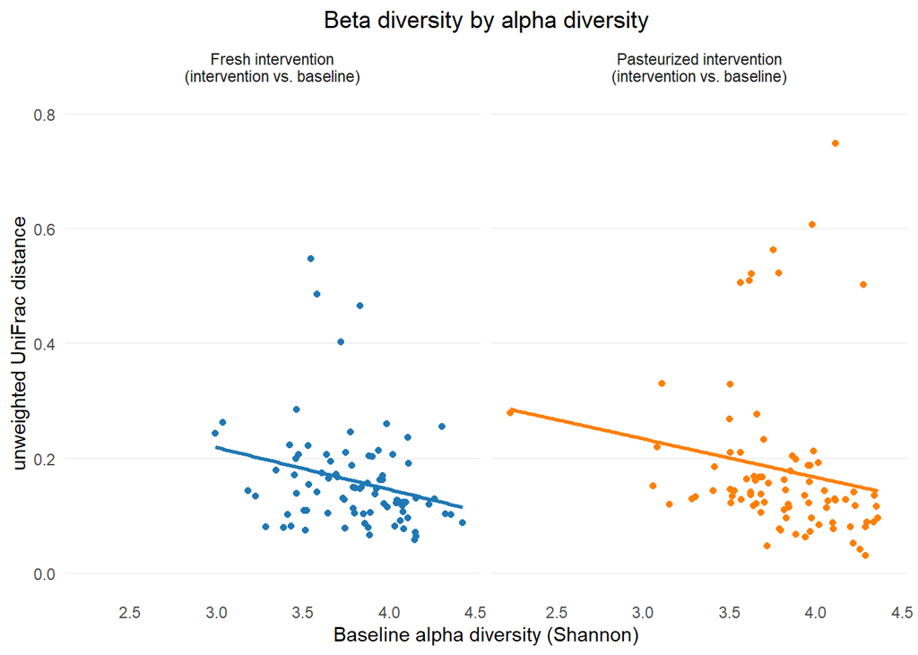

```r
# plot with metric alpha diversity
gg_betaVSalpha_uuf <- dat_comparison2 %>%
  mutate(comparison_group = case_when(comparison_group == "fresh intervention" ~ "Fresh intervention\n(intervention vs. baseline)",
                                      comparison_group == "pasteurized intervention" ~ "Pasteurized intervention\n(intervention vs. baseline)")) %>%
  ggplot(aes(x = diversity_shannon, y = uniFrac_unweighted, col = comparison_group)) +
  geom_point() +
  scale_color_manual(values = c("#1F78B4","#FF7F00")) +
  geom_smooth(se = FALSE, method = "lm") +
  facet_wrap(~ comparison_group) +
  ggtitle("Beta diversity by alpha diversity") +
  xlab("Baseline alpha diversity (Shannon)") +
  scale_y_continuous("unweighted UniFrac distance", limits = c(0, .8)) +
  theme(legend.position    = "none",
        panel.grid.minor   = element_blank(),
        panel.grid.major.x = element_blank(),
        panel.grid.major.y = element_line(color = "gray95"))
gg_betaVSalpha_uuf
```

```r
# ggsave("betaDivByAlphaDiv_unweightedUniFrac.png", width = 6.8, height = 5)

# correlation test in each comparison group
corrTest_fresh_uuf <- cor.test(x = dat_comparison2$diversity_shannon[dat_comparison2$comparison_group == "fresh intervention"],
                               y = dat_comparison2$uniFrac_unweighted[dat_comparison2$comparison_group == "fresh intervention"])
corrTest_past_uuf  <- cor.test(x = dat_comparison2$diversity_shannon[dat_comparison2$comparison_group == "pasteurized intervention"],
                               y = dat_comparison2$uniFrac_unweighted[dat_comparison2$comparison_group == "pasteurized intervention"])
```

Correlation between beta and baseline alpha diversity in the fresh intervention group: -0.25 (p = 0.0203)  
Correlation between beta and baseline alpha diversity in the pasteurized intervention group: -0.17 (p = 0.1147)

# Inter-personal variation

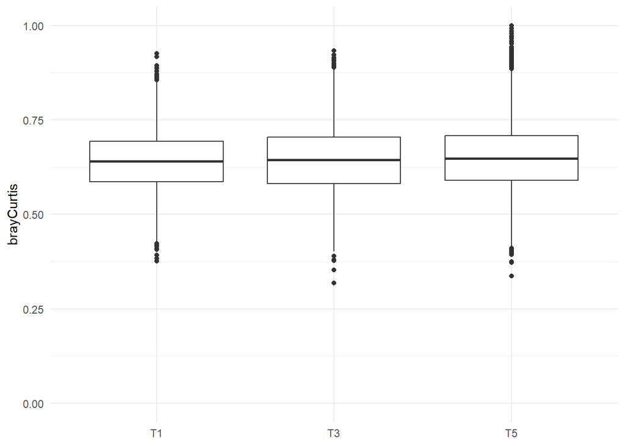

```r
datDist_inter %>%
  filter(timepoint_group == "baselines") %>%
  ggplot(aes(x = timepoint, y = brayCurtis)) +
  geom_boxplot() +
  ylim(c(0,1)) +
  theme(axis.title.x = element_blank())
```

# Intra-personal comparison of Bray-Curtis with UniFrac

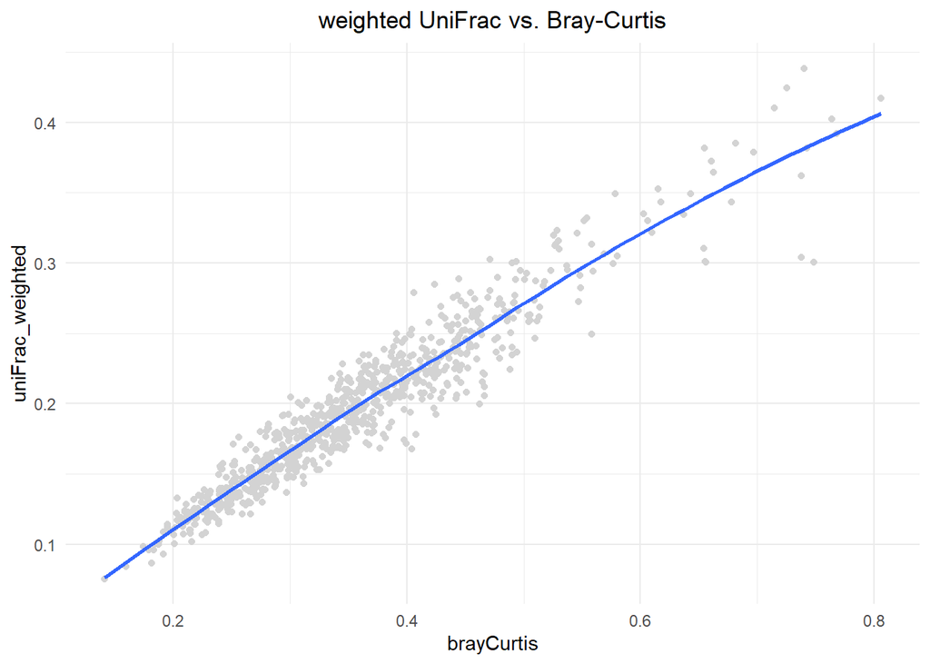

```r
ggplot(datDist_intra, aes(x = brayCurtis, y = uniFrac_weighted)) +
  geom_point(col = "lightgray") +
  geom_smooth(se = FALSE) +
  ggtitle("weighted UniFrac vs. Bray-Curtis")
```

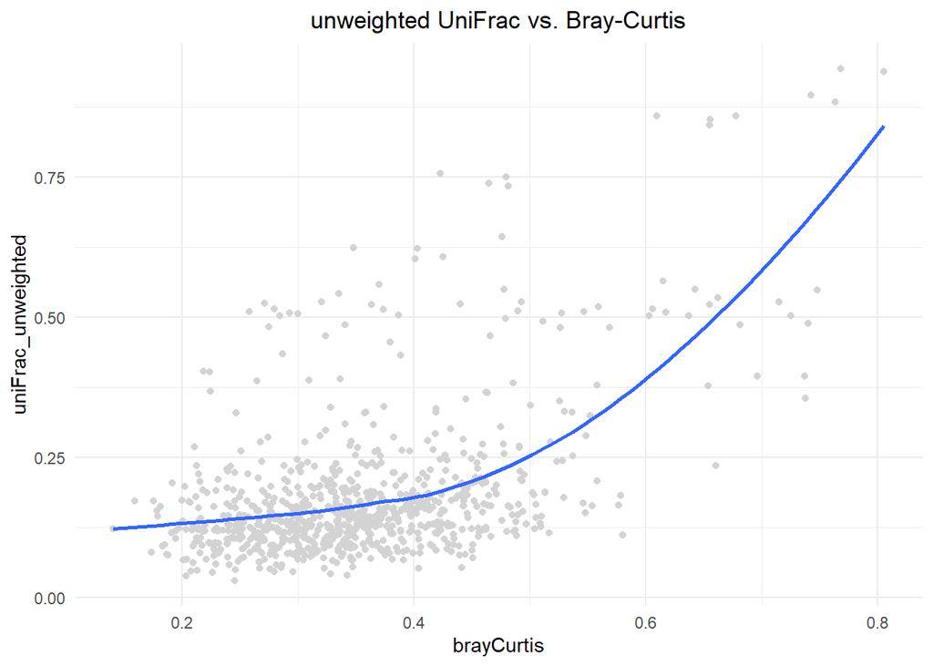

```r
ggplot(datDist_intra, aes(x = brayCurtis, y = uniFrac_unweighted)) +
  geom_point(col = "lightgray") +
  geom_smooth(se = FALSE) +
  ggtitle("unweighted UniFrac vs. Bray-Curtis")
```

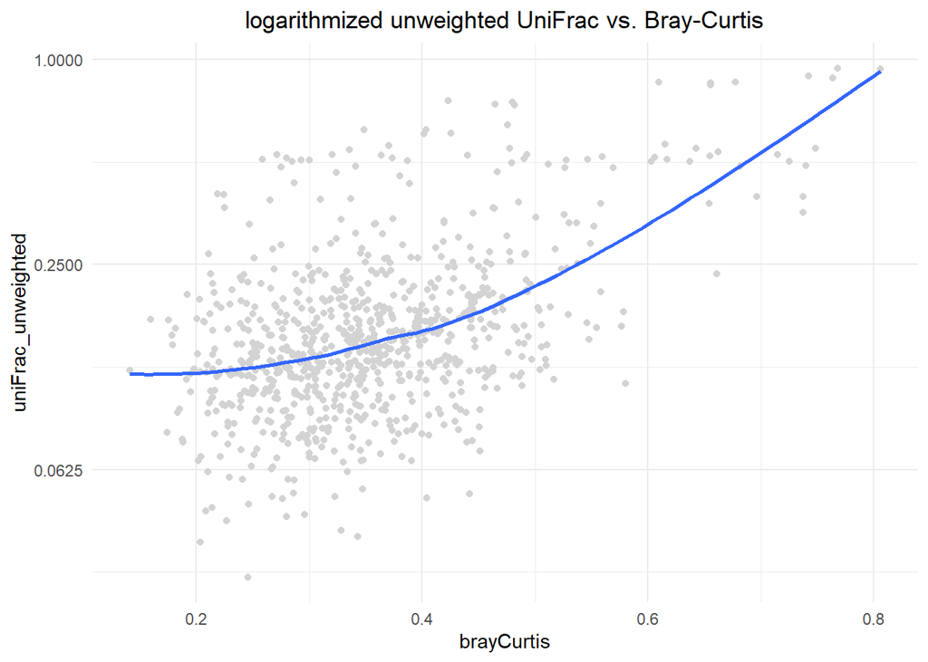

```r
ggplot(datDist_intra, aes(x = brayCurtis, y = uniFrac_unweighted)) +
  geom_point(col = "lightgray") +
  scale_y_continuous(trans = "log2") +
  geom_smooth(se = FALSE) +
  ggtitle("logarithmized unweighted UniFrac vs. Bray-Curtis")
```

# Intra-personal comparison of Bray-Curtis with UMAP distances

```r
# put the data preparation in a function, s.t. it's easily applicable also to subgroups in dat_UMAP
create_changeDat <- function(dat_UMAP) {
  # create the location dataset
  dat_change <- dat_UMAP %>%
    dplyr::rename(x = UMAP1,
                  y = UMAP2) %>%
    select(participant_id, intervention, timepoint, x, y) %>%
    pivot_wider(id_cols = participant_id, names_from = timepoint, values_from = c("x", "y")) %>%
    arrange(participant_id)

  # add the directional change variables
  dat_change <- dat_change %>%
    mutate(xChange_T1toT2           = x_T2 - x_T1,
           yChange_T1toT2           = y_T2 - y_T1,
           totalAbsChange_T1toT2    = abs(xChange_T1toT2) + abs(yChange_T1toT2),
           totalAvgAbsChange_T1toT2 = totalAbsChange_T1toT2 / 2,
           xChange_T2toT3           = x_T3 - x_T2,
           yChange_T2toT3           = y_T3 - y_T2,
           totalAbsChange_T2toT3    = abs(xChange_T2toT3) + abs(yChange_T2toT3),
           totalAvgAbsChange_T2toT3 = totalAbsChange_T2toT3 / 2,
           xChange_T3toT4           = x_T4 - x_T3,
           yChange_T3toT4           = y_T4 - y_T3,
           totalAbsChange_T3toT4    = abs(xChange_T3toT4) + abs(yChange_T3toT4),
           totalAvgAbsChange_T3toT4 = totalAbsChange_T3toT4 / 2)

  if ("x_T5" %in% colnames(dat_change)) {
    dat_change <- dat_change %>%
      mutate(xChange_T4toT5           = x_T5 - x_T4,
             yChange_T4toT5           = y_T5 - y_T4,
             totalAbsChange_T4toT5    = abs(xChange_T4toT5) + abs(yChange_T4toT5),
             totalAvgAbsChange_T4toT5 = totalAbsChange_T4toT5 / 2)
  } else {
    dat_change <- dat_change %>%
      mutate(xChange_T4toT5           = NA,
             yChange_T4toT5           = NA,
             totalAbsChange_T4toT5    = NA,
             totalAvgAbsChange_T4toT5 = NA)
  }

  # add the overall change variable
  dat_change <- dat_change %>%
    mutate(n_observedChanges       = as.numeric(!is.na(totalAbsChange_T1toT2)) + as.numeric(!is.na(totalAbsChange_T2toT3)) +
             as.numeric(!is.na(totalAbsChange_T3toT4)) + as.numeric(!is.na(totalAbsChange_T4toT5))) %>%
    rowwise() %>%
    mutate(totalAbsChange_total    = sum(c(totalAbsChange_T1toT2, totalAbsChange_T2toT3, totalAbsChange_T3toT4, totalAbsChange_T4toT5), na.rm = TRUE),
           totalAvgAbsChange_total = totalAbsChange_total / (2*n_observedChanges),
           xAbsChange_total        = sum(abs(c(xChange_T1toT2, xChange_T2toT3, xChange_T3toT4, xChange_T4toT5)), na.rm = TRUE),
           xAvgAbsChange_total     = xAbsChange_total / n_observedChanges,
           yAbsChange_total        = sum(abs(c(yChange_T1toT2, yChange_T2toT3, yChange_T3toT4, yChange_T4toT5)), na.rm = TRUE),
           yAvgAbsChange_total     = yAbsChange_total / n_observedChanges)

  # add a avgAbsBaselineChange variable, containing the average pairwise change between T1, T3, T5, averaged over x and y
  dat_change <- dat_change %>%
    rowwise() %>%
    mutate(xChange_T1toT3 = x_T3 - x_T1,
           xChange_T1toT5 = x_T5 - x_T1,
           xChange_T3toT5 = x_T5 - x_T3,
           yChange_T1toT3 = y_T3 - y_T1,
           yChange_T1toT5 = y_T5 - y_T1,
           yChange_T3toT5 = y_T5 - y_T3,
           avgAbsBaselineChange = sum(abs(c(xChange_T1toT3, xChange_T1toT5, xChange_T3toT5,
                                            yChange_T1toT3, yChange_T1toT5, yChange_T3toT5)), na.rm = TRUE) / 6,
           avgAbsBaselineChange_T1toT3 = sum(abs(c(xChange_T1toT3, yChange_T1toT3)), na.rm = TRUE) / 2,
           avgAbsBaselineChange_T1toT5 = sum(abs(c(xChange_T1toT5, yChange_T1toT5)), na.rm = TRUE) / 2,
           avgAbsBaselineChange_T3toT5 = sum(abs(c(xChange_T3toT5, yChange_T3toT5)), na.rm = TRUE) / 2)

  dat_change
}
```

```r
dat_change <- create_changeDat(dat_UMAP)
```

Note: The comparison doesn’t include all pairwise intra-personal timepoint comparisons, simply to save some time, since not all of these comparisons were already calculated in the existing codebase.

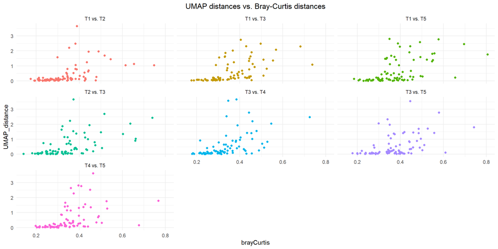

```r
# prepare the UMAP distance data
datDist_UMAP <- dat_change %>%
  select(participant_id, contains("toT")) %>%
  select(-starts_with("x"), -starts_with("y"), -starts_with("totalAbsC"), -contains("_total")) %>%
  pivot_longer(cols = contains("toT"), names_to = "comparison", values_to = "UMAP_distance") %>%
  mutate(comparison = sapply(comparison, function(x) { strsplit(x, split = "\\_")[[1]][2] }),
         comparison = gsub(comparison, pattern = "to", replacement = " vs. "))

# join the Bray-Curtis and the UMAP distance data
dat_comparison <- datDist_intra %>%
  dplyr::left_join(datDist_UMAP, by = c("participant_id", "comparison")) %>%
  filter(!is.na(UMAP_distance))

# plot the differences
ggplot(dat_comparison, aes(x = brayCurtis, y = UMAP_distance, color = comparison)) +
  geom_point() +
  facet_wrap(~ comparison) +
  ggtitle("UMAP distances vs. Bray-Curtis distances") +
  theme(legend.position = "none")
```

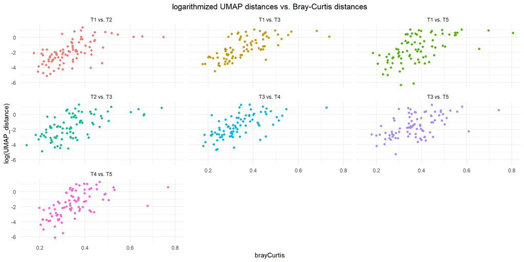

```r
ggplot(dat_comparison, aes(x = brayCurtis, y = log(UMAP_distance), color = comparison)) +
  geom_point() +
  facet_wrap(~ comparison) +
  ggtitle("logarithmized UMAP distances vs. Bray-Curtis distances") +
  theme(legend.position = "none")
```

```r
cor_UMAP_BC <- cor(dat_comparison$UMAP_distance, dat_comparison$brayCurtis, method = "spearman")
```

Spearman correlation between the UMAP distances and the Bray-Curtis distances: 0.63

## UMAP distance vs. baseline alpha diversity

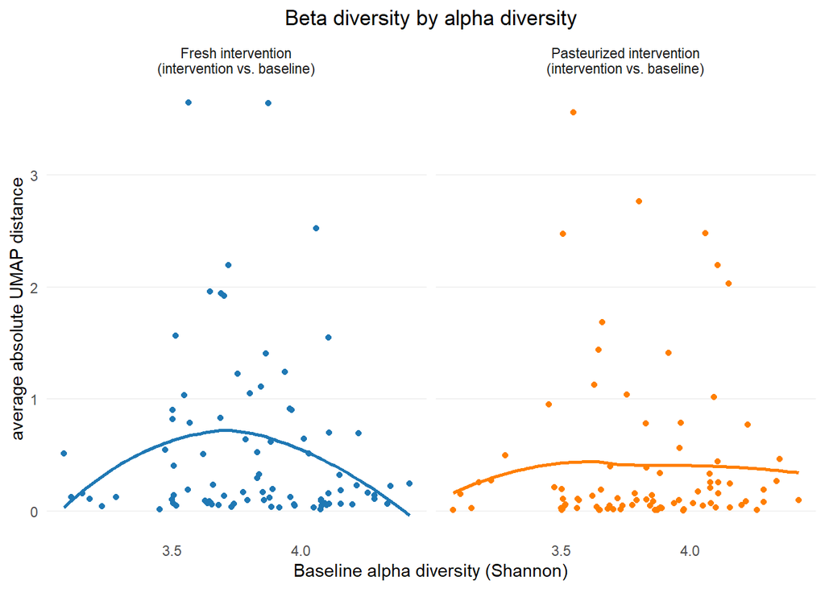

```r
# plot with metric alpha diversity
dat_comparison <- data.frame(participant_id   = rep(dat_change$participant_id, times = 2),
                             comparison       = rep(c("T1 vs. T2", "T3 vs. T4"), each = nrow(dat_change)),
                             UMAP_distance    = c(dat_change$totalAvgAbsChange_T1toT2, dat_change$totalAvgAbsChange_T3toT4)) %>%
  dplyr::left_join(dat %>% filter(timepoint == "T1") %>% select(participant_id, diversity_shannon, group), by = "participant_id") %>%
  mutate(comparison_group = case_when((comparison == "T1 vs. T2") & (group == "Fresh first") ~ "fresh intervention",
                                      comparison == "T1 vs. T2"                              ~ "pasteurized intervention",
                                      group == "Fresh first"                                 ~ "pasteurized intervention",
                                      TRUE                                                   ~ "fresh intervention")) %>%
  filter(!is.na(UMAP_distance))

dat_comparison %>%
  mutate(comparison_group = case_when(comparison_group == "fresh intervention" ~ "Fresh intervention\n(intervention vs. baseline)",
                                      comparison_group == "pasteurized intervention" ~ "Pasteurized intervention\n(intervention vs. baseline)")) %>%
  ggplot(aes(x = diversity_shannon, y = UMAP_distance, col = comparison_group)) +
  geom_point() +
  scale_color_manual(values = c("#1F78B4","#FF7F00")) +
  geom_smooth(se = FALSE, span = 1) +
  facet_wrap(~ comparison_group) +
  ggtitle("Beta diversity by alpha diversity") +
  xlab("Baseline alpha diversity (Shannon)") +
  scale_y_continuous("average absolute UMAP distance") +
  theme(legend.position    = "none",
        panel.grid.minor   = element_blank(),
        panel.grid.major.x = element_blank(),
        panel.grid.major.y = element_line(color = "gray95"))
```

```r
# ggsave("betaDivByAlphaDiv_UMAP.png", width = 6.8, height = 5)

# correlation test in each comparison group (based on GAMs, as of the nonlinearities)
m_fresh <- gam(UMAP_distance ~ s(diversity_shannon, bs = "ps"), data = dat_comparison %>% filter(comparison_group == "fresh intervention"))
# summary(m_fresh)
m_past  <- gam(UMAP_distance ~ s(diversity_shannon, bs = "ps"), data = dat_comparison %>% filter(comparison_group == "pasteurized intervention"))
```

Association between beta and baseline alpha diversity in the fresh intervention group (tested based on a GAM model, as of the nonlinearities): 0.2037)  
Association between beta and baseline alpha diversity in the pasteurized intervention group (tested based on a GAM model, as of the nonlinearities): 0.9343)

# Intra-personal model estimation on Bray-Curtis

For the model, only look at the comparisons ‘T1 vs. T3’ (baseline), ‘T1 vs. T2’ (intervention 1) and ‘T3 vs. T4’ (intervention 2).

```r
# data preparation
dat_model <- datDist_intra %>%
  filter(comparison %in% c("T1 vs. T3", "T1 vs. T2", "T3 vs. T4")) %>%
  dplyr::left_join(dat %>% select(participant_id, timepoint, dominant_species),
                   by = c("participant_id" = "participant_id",
                          "timepoint_1" = "timepoint")) %>%
  select(-intervention) %>%
  dplyr::rename(intervention = comparison_group)

# model estimation
m <- gam(brayCurtis ~ intervention + gender + age + bmi_t0 + diversity_shannon, # + s(participant_id, bs = "re"),
         data = dat_model)

# model results
summary(m)
```

```
Family: gaussian
Link function: identity

Formula:
brayCurtis ~ intervention + gender + age + bmi_t0 + diversity_shannon

Parametric coefficients:
                                       Estimate Std. Error t value Pr(>|t|)
(Intercept)                           0.3216231  0.0940153   3.421  0.00073 ***
interventionfresh intervention       -0.0198714  0.0156801  -1.267  0.20624
interventionpasteurized intervention -0.0227548  0.0157267  -1.447  0.14919
genderW                               0.0074136  0.0136613   0.543  0.58784
age                                   0.0002906  0.0004724   0.615  0.53897
bmi_t0                                0.0003203  0.0023401   0.137  0.89123
diversity_shannon                     0.0028537  0.0202217   0.141  0.88789
---
Signif. codes:  0 '***' 0.001 '**' 0.01 '*' 0.05 '.' 0.1 ' ' 1


R-sq.(adj) =  -0.0108   Deviance explained = 1.31%
GCV = 0.010739  Scale est. = 0.010444  n = 255
```

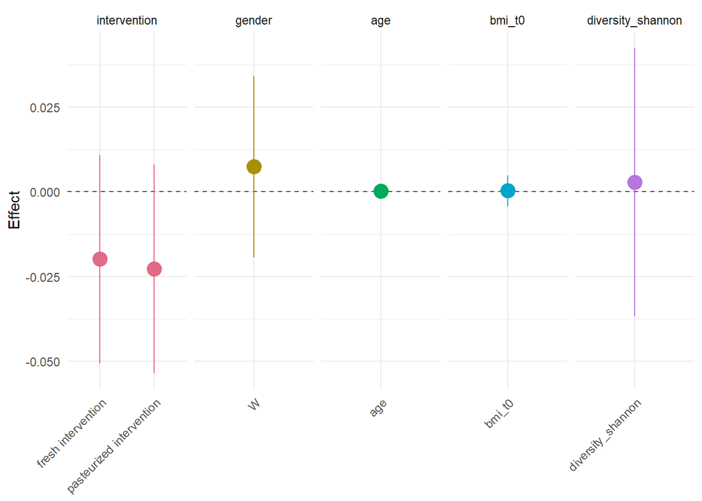

```r
APCtools::plot_linearEffects(m)
```

# Joint figures for publication

## Supplements: UMAP and Bray-Curtis

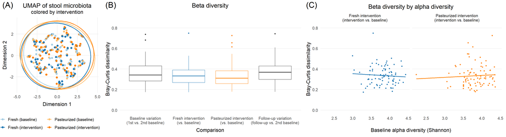

```r
# 1) UMAP
plot_dimRed_list <- plot_dimReduction(tse                = tse,
                                      dimReduction_name  = "UMAP",
                                      assay              = "relAbd",
                                      taxRank_dominance  = "phylum",
                                      taxRank_topNfocus  = 12)
gg1 <- plot_dimRed_list$gg_interventionTimes_v2 +
  labs(title = "UMAP of stool microbiota", subtitle = "colored by intervention",
       tag = "(A)") +
  xlab("Dimension 1") +
  guides(color = guide_legend(nrow = 2)) +
  theme_minimal(base_size = 16) +
  theme(plot.title        = element_text(hjust = 0.5, margin = margin(t = 2, b = 3)),
        plot.tag.location = "plot",
        plot.tag          = element_text(size = 25, margin = margin(t = -5)),
        plot.subtitle     = element_text(hjust = 0.5),
        plot.background   = element_rect(fill = "white", color = "white"),
        panel.grid.major  = element_line(color = "gray95"),
        panel.grid.minor  = element_blank(),
        legend.position   = "bottom",
        axis.title.x      = element_text(margin = margin(t = 10)),
        legend.margin     = margin(t = 0, l = 2))
gg1_legend <- ggpubr::get_legend(gg1) %>% ggpubr::as_ggplot()
gg1        <- gg1 + theme(legend.position = "none")

# 2) Bray-Curtis beta diversity boxplots
gg2 <- gg_betaDiv_bc +
  labs(title = "Beta diversity", subtitle = "", tag = "(B)") +
  ggtitle("Beta diversity", "") +
  xlab("Comparison") +
  theme_minimal(base_size = 16) +
  theme(plot.title         = element_text(hjust = 0.5, margin = margin(b = -20, t = -3.9)),
        plot.tag.location  = "plot",
        plot.tag           = element_text(size = 25, margin = margin(t = -10.5)),
        panel.grid.minor   = element_blank(),
        panel.grid.major.x = element_blank(),
        panel.grid.major.y = element_line(color = "gray95"),
        axis.title.x       = element_text(margin = margin(t = 10)),
        legend.position    = "none")


# 3) Scatterplots Bray-Curtis beta diversity vs. baseline alpha diversity
gg3 <- gg_betaVSalpha +
  labs(tag = "(C)") +
  theme_minimal(base_size = 16) +
  theme(plot.title         = element_text(hjust = 0.5, margin = margin(b = -18.5)),
        plot.tag.location  = "plot",
        plot.tag           = element_text(size = 25, margin = margin(t = -10.5)),
        panel.grid.minor   = element_blank(),
        panel.grid.major.x = element_blank(),
        panel.grid.major.y = element_line(color = "gray95"),
        axis.title.x       = element_text(margin = margin(t = 10)),
        legend.position    = "none")


# create joint plot
ggpubr::ggarrange(gg1, gg1_legend, nrow = 2, heights = c(.8, .2)) %>%
  ggpubr::ggarrange((gg2 + gg3), nrow = 1, widths = c(.2,.8)) +
  theme(plot.background  = element_rect(fill = "white", color = "white"))
```

```r
# ggsave("FigureS3_betaDiversity_brayCurtis.png", width = 22, height = 6)
```

## Main paper: Same figure with unweighted UniFrac instead of Bray-Curtis

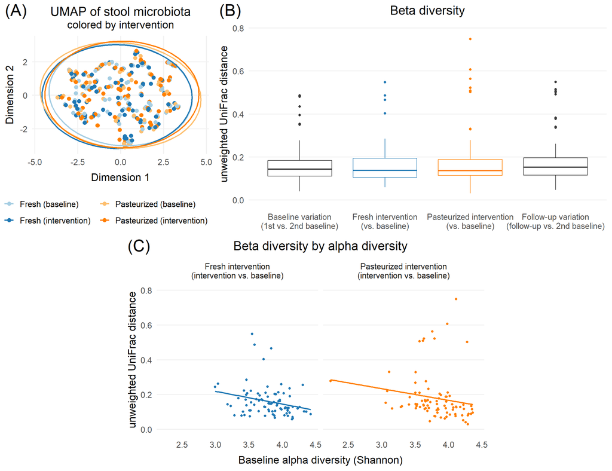

```r
# 1) UMAP
# the 'gg1' object is already created in the code chunk above

# 2) Bray-Curtis beta diversity boxplots
gg2 <- gg_betaDiv_uuf +
  labs(title = "Beta diversity", subtitle = "", tag = "(B)") +
  ggtitle("Beta diversity", "") +
  # xlab("Comparison") +
  theme_minimal(base_size = 16) +
  theme(plot.title         = element_text(hjust = 0.5, margin = margin(b = -20)),
        plot.tag.location  = "plot",
        plot.tag           = element_text(size = 25, margin = margin(t = -5)),
        panel.grid.minor   = element_blank(),
        panel.grid.major.x = element_blank(),
        panel.grid.major.y = element_line(color = "gray95"),
        axis.title.x       = element_blank(),
        # axis.title.x       = element_text(margin = margin(t = 10)),
        legend.position    = "none")


# 3) Scatterplots Bray-Curtis beta diversity vs. baseline alpha diversity
gg3 <- gg_betaVSalpha_uuf +
  labs(tag = "(C)") +
  theme_minimal(base_size = 16) +
  theme(plot.title         = element_text(hjust = 0.5),
        plot.tag.location  = "plot",
        plot.tag           = element_text(size = 25, margin = margin(t = -5)),
        panel.grid.minor   = element_blank(),
        panel.grid.major.x = element_blank(),
        panel.grid.major.y = element_line(color = "gray95"),
        axis.title.x       = element_text(margin = margin(t = 10)),
        legend.position    = "none")


# create joint plot
# ggpubr::ggarrange(gg1, gg1_legend, nrow = 2, heights = c(.8, .2)) %>%
#   ggpubr::ggarrange((gg2 + gg3), nrow = 1, widths = c(.2,.8)) +
#   theme(plot.background  = element_rect(fill = "white", color = "white"))
ggpubr::ggarrange(
  ggpubr::ggarrange(gg1, gg1_legend, nrow = 2, heights = c(.8, .2)) %>%
    ggpubr::ggarrange(gg2, nrow = 1, widths = c(.35,.65)),
  ggpubr::ggarrange(ggplot(), gg3, ggplot(), nrow = 1, widths = c(.2, .6, .2)),
  nrow = 2
) +
  theme(plot.background  = element_rect(fill = "white", color = "white"))
```

```r
# ggsave("Figure3_betaDiversity_unweightedUniFrac.png", width = 13, height = 10)
```

# Stratified analysis by age, gender, BMI

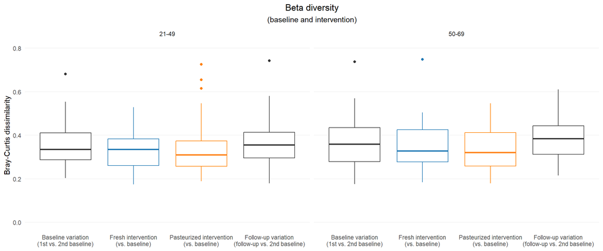

```r
# by age
datDist_intra %>%
  filter(comparison_group != "other",
         comparison != "T1 vs. T5") %>%
  mutate(comparison_group = case_when(comparison_group == "baselines" & comparison == "T1 vs. T3" ~ "Baseline variation\n(1st vs. 2nd baseline)",
                                      comparison_group == "baselines" & comparison == "T3 vs. T5" ~ "Follow-up variation\n(follow-up vs. 2nd baseline)",
                                      comparison_group == "fresh intervention"                    ~ "Fresh intervention\n(vs. baseline)",
                                      comparison_group == "pasteurized intervention"              ~ "Pasteurized intervention\n(vs. baseline)"),
         comparison_group = factor(comparison_group,
                                   levels = c("Baseline variation\n(1st vs. 2nd baseline)", "Fresh intervention\n(vs. baseline)",
                                              "Pasteurized intervention\n(vs. baseline)", "Follow-up variation\n(follow-up vs. 2nd baseline)"))) %>%
  ggplot(aes(x = comparison_group, y = brayCurtis, col = comparison_group)) +
  geom_boxplot() +
  scale_y_continuous("Bray-Curtis dissimilarity", limits = c(0, .8)) +
  scale_color_manual(values = c("gray20","#1F78B4","#FF7F00","gray20")) +
  facet_wrap(~ age_cat) +
  ggtitle("Beta diversity", "(baseline and intervention)") +
  theme(axis.title.x    = element_blank(),
        legend.position = "none",
        panel.grid.minor   = element_blank(),
        panel.grid.major.x = element_blank(),
        panel.grid.major.y = element_line(color = "gray95"))
```

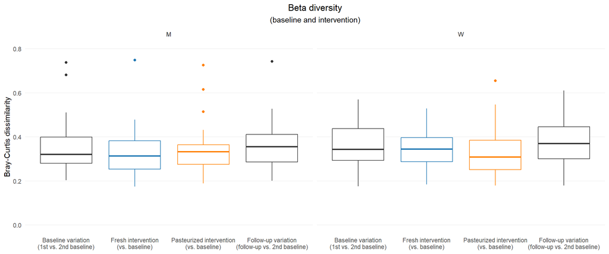

```r
# by gender
datDist_intra %>%
  filter(comparison_group != "other",
         comparison != "T1 vs. T5") %>%
  mutate(comparison_group = case_when(comparison_group == "baselines" & comparison == "T1 vs. T3" ~ "Baseline variation\n(1st vs. 2nd baseline)",
                                      comparison_group == "baselines" & comparison == "T3 vs. T5" ~ "Follow-up variation\n(follow-up vs. 2nd baseline)",
                                      comparison_group == "fresh intervention"                    ~ "Fresh intervention\n(vs. baseline)",
                                      comparison_group == "pasteurized intervention"              ~ "Pasteurized intervention\n(vs. baseline)"),
         comparison_group = factor(comparison_group,
                                   levels = c("Baseline variation\n(1st vs. 2nd baseline)", "Fresh intervention\n(vs. baseline)",
                                              "Pasteurized intervention\n(vs. baseline)", "Follow-up variation\n(follow-up vs. 2nd baseline)"))) %>%
  ggplot(aes(x = comparison_group, y = brayCurtis, col = comparison_group)) +
  geom_boxplot() +
  scale_y_continuous("Bray-Curtis dissimilarity", limits = c(0, .8)) +
  scale_color_manual(values = c("gray20","#1F78B4","#FF7F00","gray20")) +
  facet_wrap(~ gender) +
  ggtitle("Beta diversity", "(baseline and intervention)") +
  theme(axis.title.x    = element_blank(),
        legend.position = "none",
        panel.grid.minor   = element_blank(),
        panel.grid.major.x = element_blank(),
        panel.grid.major.y = element_line(color = "gray95"))
```

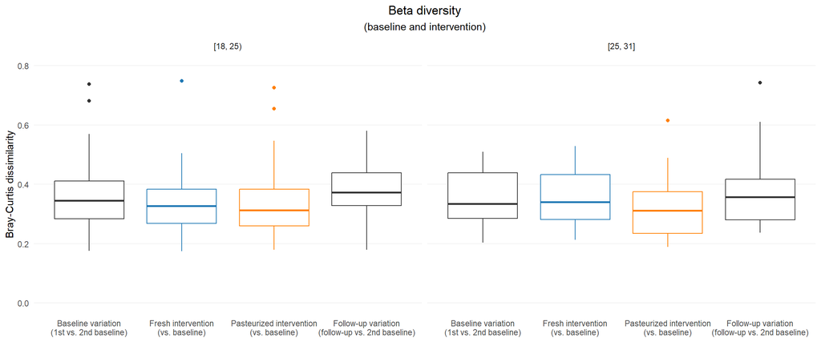

```r
# by BMI
datDist_intra %>%
  filter(comparison_group != "other",
         comparison != "T1 vs. T5") %>%
  mutate(comparison_group = case_when(comparison_group == "baselines" & comparison == "T1 vs. T3" ~ "Baseline variation\n(1st vs. 2nd baseline)",
                                      comparison_group == "baselines" & comparison == "T3 vs. T5" ~ "Follow-up variation\n(follow-up vs. 2nd baseline)",
                                      comparison_group == "fresh intervention"                    ~ "Fresh intervention\n(vs. baseline)",
                                      comparison_group == "pasteurized intervention"              ~ "Pasteurized intervention\n(vs. baseline)"),
         comparison_group = factor(comparison_group,
                                   levels = c("Baseline variation\n(1st vs. 2nd baseline)", "Fresh intervention\n(vs. baseline)",
                                              "Pasteurized intervention\n(vs. baseline)", "Follow-up variation\n(follow-up vs. 2nd baseline)"))) %>%
  ggplot(aes(x = comparison_group, y = brayCurtis, col = comparison_group)) +
  geom_boxplot() +
  scale_y_continuous("Bray-Curtis dissimilarity", limits = c(0, .8)) +
  scale_color_manual(values = c("gray20","#1F78B4","#FF7F00","gray20")) +
  facet_wrap(~ bmi_cat) +
  ggtitle("Beta diversity", "(baseline and intervention)") +
  theme(axis.title.x    = element_blank(),
        legend.position = "none",
        panel.grid.minor   = element_blank(),
        panel.grid.major.x = element_blank(),
        panel.grid.major.y = element_line(color = "gray95"))
```

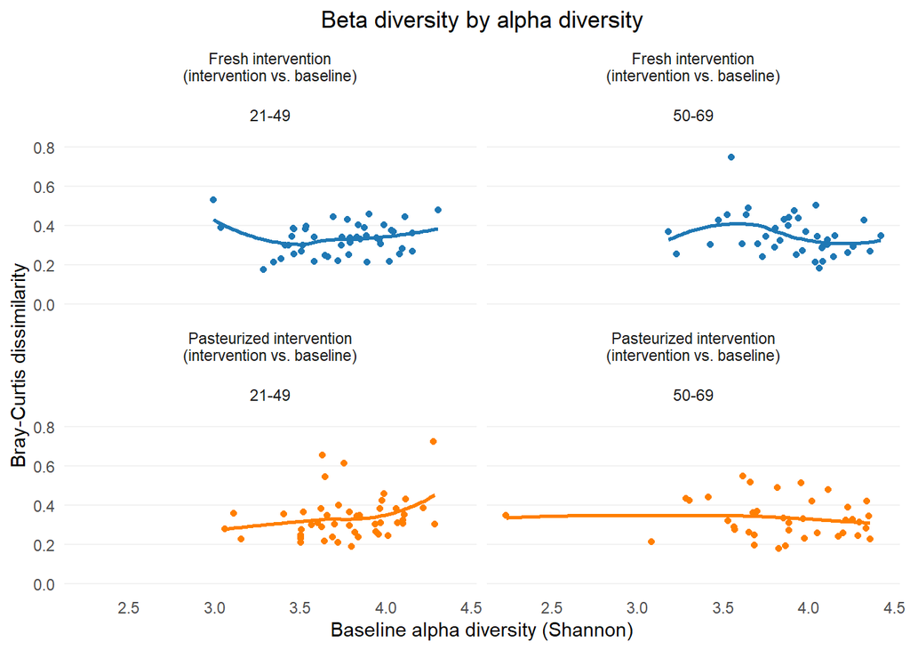

```r
# by age
dat_comparison2 %>%
  mutate(comparison_group = case_when(comparison_group == "fresh intervention" ~ "Fresh intervention\n(intervention vs. baseline)",
                                      comparison_group == "pasteurized intervention" ~ "Pasteurized intervention\n(intervention vs. baseline)")) %>%
  ggplot(aes(x = diversity_shannon, y = brayCurtis, col = comparison_group)) +
  geom_point() +
  scale_color_manual(values = c("#1F78B4","#FF7F00")) +
  geom_smooth(se = FALSE, span = 1) +
  facet_wrap(~ comparison_group + age_cat) +
  ggtitle("Beta diversity by alpha diversity") +
  xlab("Baseline alpha diversity (Shannon)") +
  scale_y_continuous("Bray-Curtis dissimilarity", limits = c(0, .8)) +
  theme(legend.position    = "none",
        panel.grid.minor   = element_blank(),
        panel.grid.major.x = element_blank(),
        panel.grid.major.y = element_line(color = "gray95"))
```

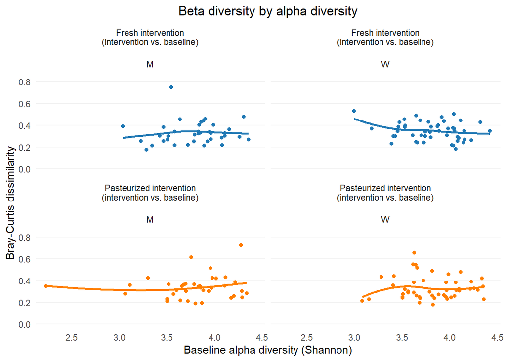

```r
# by gender
dat_comparison2 %>%
  mutate(comparison_group = case_when(comparison_group == "fresh intervention" ~ "Fresh intervention\n(intervention vs. baseline)",
                                      comparison_group == "pasteurized intervention" ~ "Pasteurized intervention\n(intervention vs. baseline)")) %>%
  ggplot(aes(x = diversity_shannon, y = brayCurtis, col = comparison_group)) +
  geom_point() +
  scale_color_manual(values = c("#1F78B4","#FF7F00")) +
  geom_smooth(se = FALSE, span = 1) +
  facet_wrap(~ comparison_group + gender) +
  ggtitle("Beta diversity by alpha diversity") +
  xlab("Baseline alpha diversity (Shannon)") +
  scale_y_continuous("Bray-Curtis dissimilarity", limits = c(0, .8)) +
  theme(legend.position    = "none",
        panel.grid.minor   = element_blank(),
        panel.grid.major.x = element_blank(),
        panel.grid.major.y = element_line(color = "gray95"))
```

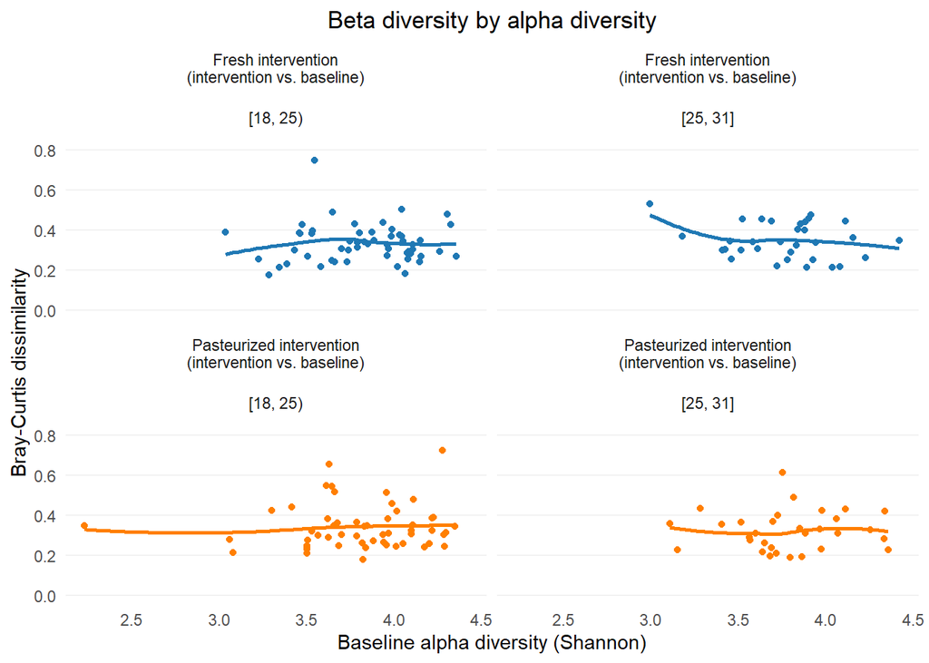

```r
# by BMI
dat_comparison2 %>%
  mutate(comparison_group = case_when(comparison_group == "fresh intervention" ~ "Fresh intervention\n(intervention vs. baseline)",
                                      comparison_group == "pasteurized intervention" ~ "Pasteurized intervention\n(intervention vs. baseline)")) %>%
  ggplot(aes(x = diversity_shannon, y = brayCurtis, col = comparison_group)) +
  geom_point() +
  scale_color_manual(values = c("#1F78B4","#FF7F00")) +
  geom_smooth(se = FALSE, span = 1) +
  facet_wrap(~ comparison_group + bmi_cat) +
  ggtitle("Beta diversity by alpha diversity") +
  xlab("Baseline alpha diversity (Shannon)") +
  scale_y_continuous("Bray-Curtis dissimilarity", limits = c(0, .8)) +
  theme(legend.position    = "none",
        panel.grid.minor   = element_blank(),
        panel.grid.major.x = element_blank(),
        panel.grid.major.y = element_line(color = "gray95"))
```

# PCoA of inter-personal distances

Code source: https://microbiome.github.io/course_2021_radboud/beta-diversity.html

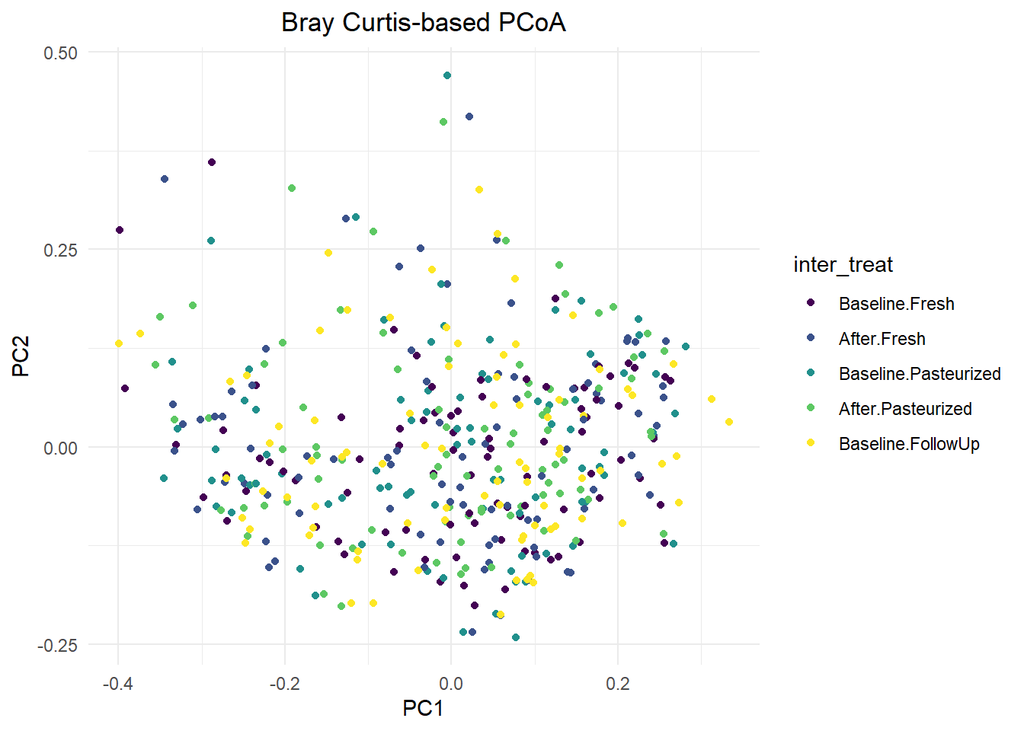

```r
# Pick the relative abundance table
rel_abund_assay <- assays(tse)$relAbd

# Calculates Bray-Curtis distances between samples. Because taxa is in
# columns, it is used to compare different samples. We transpose the
# assay to get taxa to columns
bray_curtis_dist <- vegan::vegdist(t(rel_abund_assay), method = "bray")

# PCoA
bray_curtis_pcoa <- ecodist::pco(bray_curtis_dist)

# All components could be found here:
# bray_curtis_pcoa$vectors
# But we only need the first two to demonstrate what we can do:
bray_curtis_pcoa_df <- data.frame(pcoa1 = bray_curtis_pcoa$vectors[,1],
                                  pcoa2 = bray_curtis_pcoa$vectors[,2])

# Create a plot
bray_curtis_pcoa_df %>%
  mutate(inter_treat = colData(tse)$inter_treat) %>%
  ggplot(data = ., aes(x = pcoa1, y = pcoa2, color = inter_treat)) +
  geom_point() +
  ggtitle("Bray Curtis-based PCoA") +
  xlab("PC1") + ylab("PC2")
```